# Multiverse Meta-Analysis

This notebook contains all code required for **Multiverse Meta-Analyses**, including the generation of specifications, bootstrap data, and visualizations.

## Imports

```r
library(ggplot2)
library(ggpubr)
library(metafor)
source("bootstrap.R", local = knitr::knit_global())
source("config.R", local = knitr::knit_global())
source("data.R", local = knitr::knit_global())
source("plotting.R", local = knitr::knit_global())
source("specs.R", local = knitr::knit_global())
source("user_data.R", local = knitr::knit_global())
```

## Constants

In this cell, set the **title**, the **working directory** and the **path to the dataset** for this analysis. The **config**, **preprocessed data**, **specs**, and **bootstrap data** paths depend on the working directory and the title. This naming convention can be changed, but the prefixes (i.e. `boot`, `config`, `data` and `specs`) are required for the **Dashboard** to work. The configuration file must exist, all other data can either be loaded or generated, using the boolean flags. The generated data will be stored at the specified paths, or loaded from that path.

```r
TITLE <- "R2D4D_2"
DIR <- "../examples/R2D4D"
DATA_PATH <- paste0(DIR, "/R2D4D.csv")

# TITLE <- "Chernobyl_2"
# DIR <- "../examples/Chernobyl"
# DATA_PATH <- paste0(DIR, "/Chernobyl.rda")

# TITLE = "IandR_2"
# DIR = "../examples/IandR"
# DATA_PATH = paste0(DIR, "/iandr.sav")

PREPROCESS_DATA <- F # Load (False) or preprocess data (True)
GENERATE_SPECS <- F # Load (False) or generate specs (True)
GENERATE_BOOTDATA <- F # Load (False) or generate boot data (True)

CONFIG_PATH <- paste0(DIR, "/config_", TITLE, ".json")
PP_DATA_PATH <- paste0(DIR, "/data_", TITLE, ".csv")
SPECS_PATH <- paste0(DIR, "/specs_", TITLE, ".csv")
BOOT_PATH <- paste0(DIR, "/boot_", TITLE, ".csv")
```

## Configuration

In this cell, the configuration file is processed. The cell prints out the parsed configuration, so the user can double-check if the result is as expected.

```r
config <- readConfig(CONFIG_PATH)
if (!is.null(config)) {
  c_info <- getConfigInfo(config)
  cat(c_info, sep = "\n")
}
```

```
## R2D:4D - Level 2 Meta-Analysis
##    Minimum Nr. of Samples to include Specification: 2
##    Bootstrap Iterations: 100
##    6 Which-Factors:
##      sex : men, women, all_sex
##      method : direct, image, all_method
##      age_group : adults, non-adults, all_age_group
##      sample : healthy, clinical, all_sample
##      race : white, other, all_race
##      published_estimate : yes, no, all_published_estimate
##   ( 729 Which-Factor Combinations )
##    2 How-Factors:
##      effect : r, z
##      ma_method : FE, RE_DL, REML, unweighted
##    Labels
##      sex: male
##      sex: female
##      sex: either
##      measure: direct
##      measure: image
##      measure: either
##      age: adults
##      age: non-adults
##      age: either
##      group: healthy
##      group: patients
##      group: either
##      ethnicity: White
##      ethnicity: non-White
##      ethnicity: either
##      report: full
##      report: not
##      report: either
##      metric: r
##      metric: z
##      model: FEM
##      model: REM
##      model: REML
##      model: UWM
##    Column-Map
##      key_c : Study_name
##      key_c_id : c_id
##      key_e_id : e_id
##      key_z : z
##      key_z_se : z_se
##      key_r : r
##      key_r_se : r_se
##      key_main_es : z
##      key_main_es_se : z_se
##      key_n : N
```

## Preprocess and Prepare Data

In this cell, the dataset is either preprocessed and stored at `PP_DATA_PATH`, or the preprocessed dataset is loaded from `PP_DATA_PATH`. The cell prints out the head and the dimensions of the data. If preprocessing is desired, the function `preprocessData()` must be defined by the user, in the file `user_data.R`.

```r
if (PREPROCESS_DATA) {
  ma_data <- preprocessData(DATA_PATH, title = TITLE)
} else {
  ma_data <- read.table(PP_DATA_PATH, sep = ",", header = TRUE)
}
print(dim(ma_data))
```

```
## [1] 31 14
```

```r
head(ma_data)
```

|  | Study_name | publ_yr | publ_yr_recoded | sex | age_group | sample | race | method | published_estimate | N | r | r_se | z | z_se |
| --- | --- | --- | --- | --- | --- | --- | --- | --- | --- | --- | --- | --- | --- | --- |
| 1 | Manning (2003) | 2003 | 1 | men | adults | healthy | white | direct | yes | 50 | 0.2900 | 0.1335977 | 0.298566264 | 0.1458650 |
| 2 | Latourelle (2008), men | 2008 | 6 | men | adults | healthy | white | image | no | 35 | 0.0000 | 0.1767767 | 0.000000000 | 0.1767767 |
| 3 | Latourelle (2008), women | 2008 | 6 | women | adults | healthy | white | image | no | 72 | 0.0000 | 0.1203859 | 0.000000000 | 0.1203859 |
| 4 | Mas (2009) | 2009 | 7 | men | adults | healthy | white | image | no | 72 | -0.0685 | 0.1198210 | -0.068607442 | 0.1203859 |
| 5 | Mas (2009), patients | 2009 | 7 | men | adults | clinical | white | image | no | 63 | 0.0021 | 0.1290989 | 0.002100003 | 0.1290994 |
| 6 | Hurd (2011) | 2011 | 9 | men | adults | healthy | white | image | yes | 180 | 0.0060 | 0.0751619 | 0.006000072 | 0.0751646 |

In this cell, the preprocessed dataset is prepared for meta-analysis. Preparation adds **cluster-** and **effect- IDs**, sets datatypes, etc.. For details, consult the function documentation of `prepareData()`. The cell prints out the head and the dimensions of the prepared data.

```r
data <- prepareData(config$colmap, ma_data)
print(dim(data))
```

```
## [1] 31 16
```

```r
head(data)
```

|  | c_id | Study_name | e_id | publ_yr | publ_yr_recoded | sex | age_group | sample | race | method | published_estimate | N | r | r_se | z | z_se |
| --- | --- | --- | --- | --- | --- | --- | --- | --- | --- | --- | --- | --- | --- | --- | --- | --- |
| 1 | 1 | Manning (2003) | 1 | 2003 | 1 | men | adults | healthy | white | direct | yes | 50 | 0.2900 | 0.1335977 | 0.298566264 | 0.1458650 |
| 2 | 2 | Latourelle (2008), men | 2 | 2008 | 6 | men | adults | healthy | white | image | no | 35 | 0.0000 | 0.1767767 | 0.000000000 | 0.1767767 |
| 3 | 3 | Latourelle (2008), women | 3 | 2008 | 6 | women | adults | healthy | white | image | no | 72 | 0.0000 | 0.1203859 | 0.000000000 | 0.1203859 |
| 4 | 4 | Mas (2009) | 4 | 2009 | 7 | men | adults | healthy | white | image | no | 72 | -0.0685 | 0.1198210 | -0.068607442 | 0.1203859 |
| 5 | 5 | Mas (2009), patients | 5 | 2009 | 7 | men | adults | clinical | white | image | no | 63 | 0.0021 | 0.1290989 | 0.002100003 | 0.1290994 |
| 6 | 6 | Hurd (2011) | 6 | 2011 | 9 | men | adults | healthy | white | image | yes | 180 | 0.0060 | 0.0751619 | 0.006000072 | 0.0751646 |

## Specifications

In this cell, the specifications are either generated and stored at `SPECS_PATH`, or loaded from `SPECS_PATH`. For details, consult the function documentation of `generateSpecs()`.

```r
if (GENERATE_SPECS) {
  specs <- generateSpecs(
    data,
    config$which_lists,
    config$how_lists,
    config$colmap,
    config$k_min,
    config$level,
    SPECS_PATH
  )
} else {
  specs <- read.table(SPECS_PATH, sep = ",", header = TRUE)
}
print(dim(specs))
```

```
## [1] 680  19
```

```r
head(specs)
```

|  | sex | method | age_group | sample | race | published_estimate | effect | ma_method | mean | lb | ub | p | k | set | set_es | kc | full_set | rank | ci |
| --- | --- | --- | --- | --- | --- | --- | --- | --- | --- | --- | --- | --- | --- | --- | --- | --- | --- | --- | --- |
| 1 | men | image | adults | healthy | white | no | r | FE | -0.04693626 | -0.2413334 | 0.1474609 | 0.6360534 | 2 | 2,4 | 2,4 | 2 | 0 | 1 | 0.3887943 |
| 2 | men | image | adults | healthy | white | no | r | REML | -0.04693626 | -0.2413334 | 0.1474609 | 0.6360534 | 2 | 2,4 | 2,4 | 2 | 0 | 2 | 0.3887943 |
| 3 | men | image | adults | healthy | white | no | r | RE_DL | -0.04693626 | -0.2413334 | 0.1474609 | 0.6360534 | 2 | 2,4 | 2,4 | 2 | 0 | 3 | 0.3887943 |
| 4 | men | image | adults | healthy | white | no | z | FE | -0.04683614 | -0.2372840 | 0.1470787 | 0.6376107 | 2 | 2,4 | 2,4 | 2 | 0 | 4 | 0.3843628 |
| 5 | men | image | adults | healthy | white | no | z | RE_DL | -0.04683614 | -0.2372840 | 0.1470787 | 0.6376107 | 2 | 2,4 | 2,4 | 2 | 0 | 5 | 0.3843628 |
| 6 | men | image | adults | healthy | white | no | z | REML | -0.04683614 | -0.2372840 | 0.1470787 | 0.6376107 | 2 | 2,4 | 2,4 | 2 | 0 | 6 | 0.3843628 |

## Bootstrap Data

In this cell, the bootstrap data is either generated and stored at `BOOT_PATH`, or loaded from `BOOT_PATH`. For details, consult the function documentation of `generateBootData()`.

```r
if (GENERATE_BOOTDATA) {
  boot_data <- generateBootData(
    specs,
    config$n_boot_iter,
    data,
    config$colmap,
    config$level,
    BOOT_PATH
  )
} else {
  boot_data <- read.table(BOOT_PATH, sep = ",", header = TRUE)
}
print(dim(boot_data))
```

```
## [1] 680   4
```

```r
head(boot_data)
```

|  | rank | obs | boot_lb | boot_ub |
| --- | --- | --- | --- | --- |
| 1 | 1 | -0.04693626 | -0.2168826 | -0.03052826 |
| 2 | 2 | -0.04693626 | -0.2148031 | -0.03026222 |
| 3 | 3 | -0.04693626 | -0.2097693 | -0.03024881 |
| 4 | 4 | -0.04683614 | -0.2097376 | -0.02993962 |
| 5 | 5 | -0.04683614 | -0.2084635 | -0.02773318 |
| 6 | 6 | -0.04683614 | -0.2084635 | -0.02728234 |

## Plotting

In this cell, the **cluster-** and **specification-** fill data for the respective tile maps is prepared, as well as the list of colors that constitute the color scheme. For details, consult the respective function documentation.

```r
cluster_fill_data <- getClusterFillData(data, specs, config$colmap)
spec_fill_data <- getSpecFillData(
  config$n_which,
  config$which_lists,
  config$n_how,
  config$how_lists,
  specs
)
fill_levels <- length(unique(unlist(spec_fill_data)))
colors <- getColors(fill_levels)
```

Here we define important variables for plotting that will be reused in several plots, to improve readability.

```r
colmap <- config$colmap # Column-mapping from the configuration file
k_range <- c(config$k_min, max(specs$k)) # Range of k-values (# Samples)
labels <- config$labels # Factor-labels
level <- config$level # Meta-analytic level (2 or 3)
n_total_specs <- nrow(specs) # Total number of specifications
title <- config$title # Title of Meta-Analysis
x_range <- c(1 - 0.5, n_total_specs + 0.5) # x-axis range
```

### Inferential Specification Plot

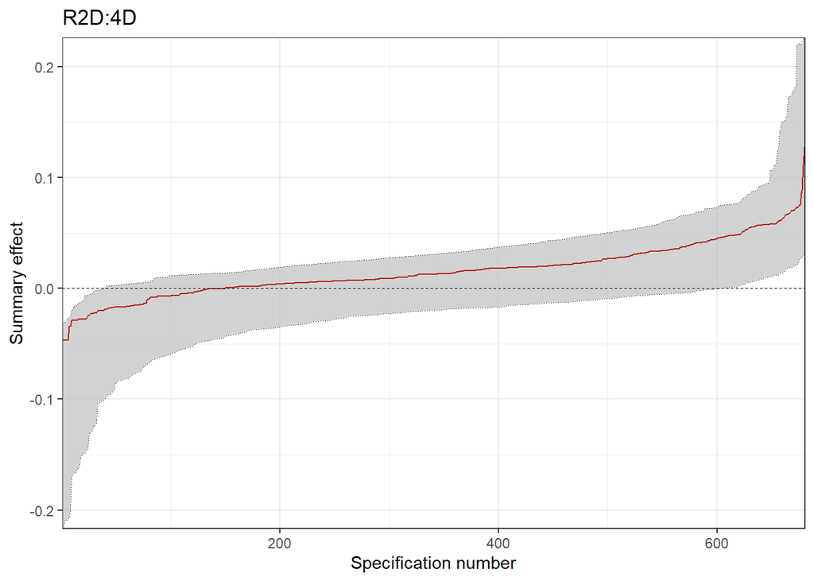

```r
fig_inferential <- plotInferential(boot_data, x_range, title)
fig_inferential
```

### p-Value Histogram

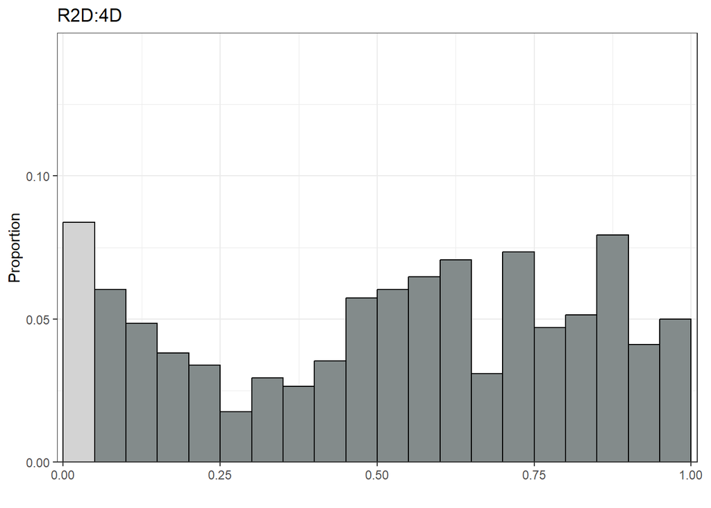

```r
fig_p_hist <- plotPValuesHist(specs, title)
fig_p_hist
```

### Multiverse

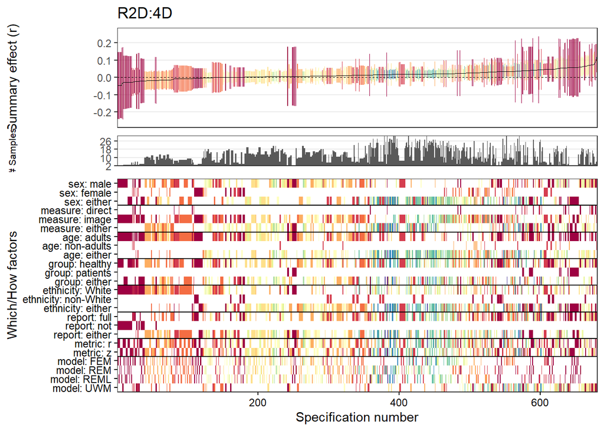

```r
fig_multiverse <- plotMultiverse(
  specs, n_total_specs, k_range, cluster_fill_data,
  spec_fill_data, labels, colors, level, title,
  x_range, fill_levels
)
fig_multiverse
```

```r
ggsave("multiverse.pdf", fig_multiverse, width = 16 * 1.2, height = 15 * 1.2, dpi = 600, units = "cm")
```

### Individual Multiverse Components

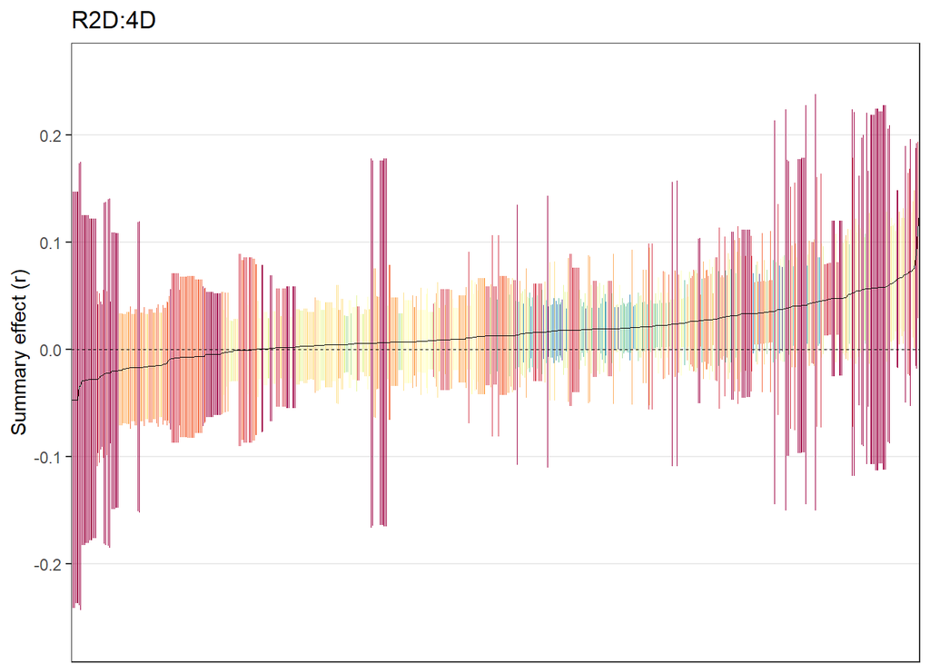

```r
fig_caterpillar <- plotCaterpillar(specs, colors, title, x_range, fill_levels)
fig_caterpillar
```

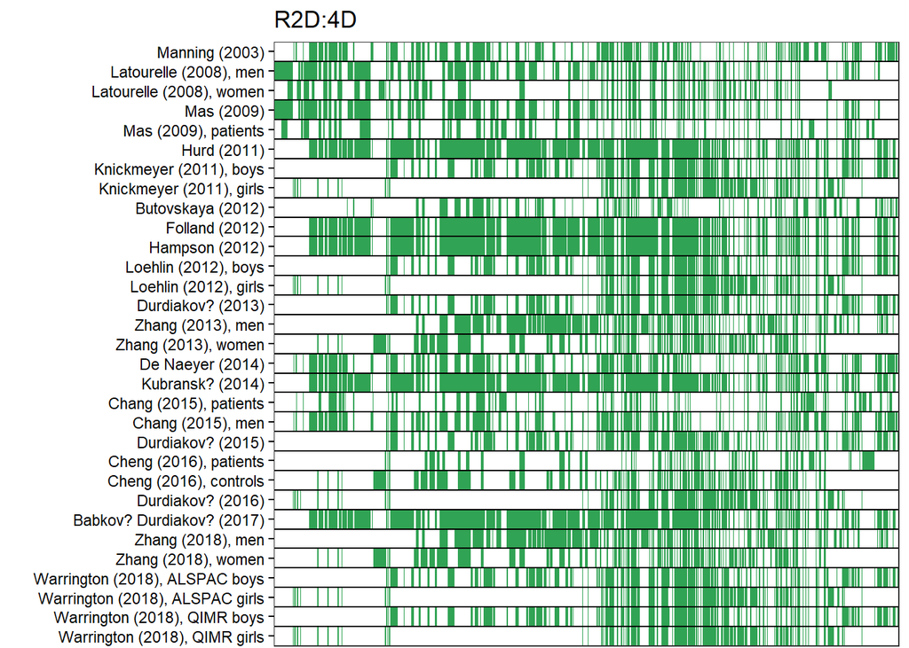

```r
fig_cluster_tiles <- plotClusterTiles(
  specs, cluster_fill_data, n_total_specs, title, x_range
)
fig_cluster_tiles
```

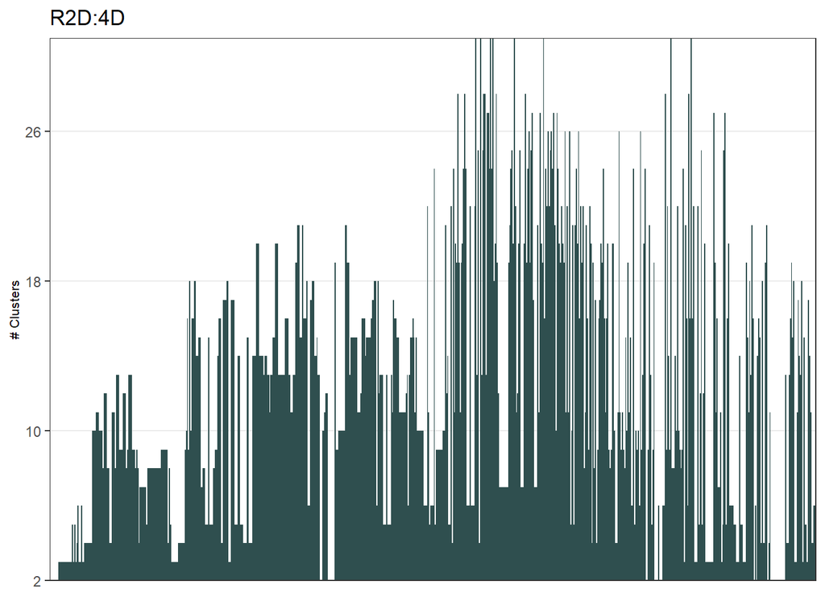

```r
fig_cluster_size <- plotClusterSize(
  specs, k_range, n_total_specs, title, x_range
)
fig_cluster_size
```

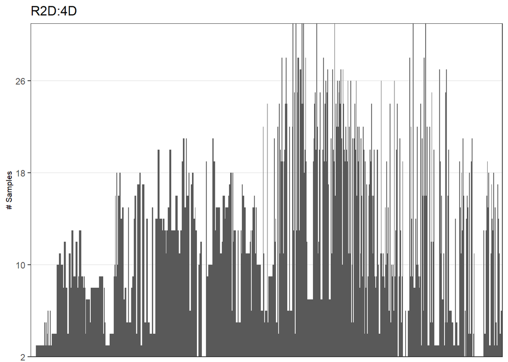

```r
fig_sample_size <- plotSampleSize(
  specs, k_range, n_total_specs, title, x_range
)
fig_sample_size
```

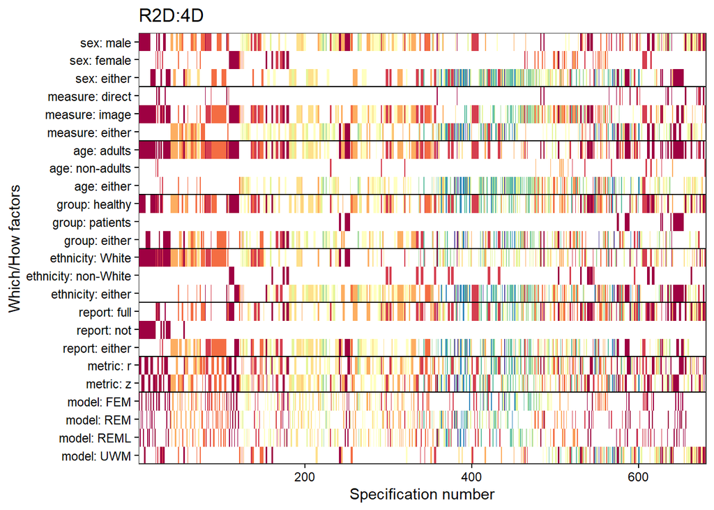

```r
fig_spec_tiles <- plotSpecTiles(
  specs, n_total_specs, spec_fill_data, labels, colors, title, x_range,
  fill_levels
)
fig_spec_tiles
```

### Rainforest

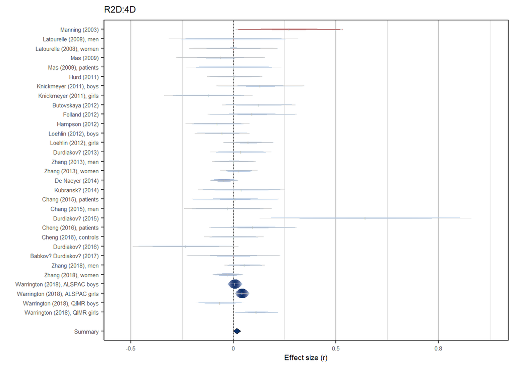

```r
fig_rainforest <- plotRainforest(data, colmap, title)
fig_rainforest
```

### Gosh

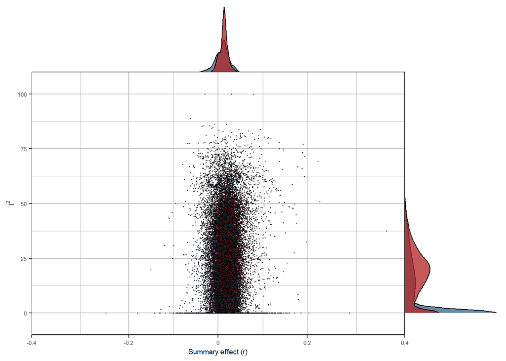

```r
fig_gosh <- plotGosh(data, colmap, title)
fig_gosh
```